# Mastering Time Series and Epicurves Visualization

# 1 Introduction

Time series visualization stands as a cornerstone in data analysis, especially when the focal point is data aggregated over various time intervals. Such visual representation enables analysts, researchers, and decision-makers to discern patterns, detect anomalies, and predict future trends, making it a powerful tool for insight generation.

In the realm of epidemiology, the significance of time series visualization amplifies. Diseases spread, populations react, and policies adapt—all in the dynamic theater of time. Indicators such as infection rates, recovery rates, mortality rates, and vaccination progress can be meticulously tracked, allowing for informed responses to health crises. Such continuous monitoring and visualization enable real-time insights into disease progression and the effectiveness of interventions.

# 2 Learning Objectives

Upon completing this lesson, participants will be able to:

- Identify the fundamental elements of an epicurve.
- Construct epicurves utilizing the ggplot2 package.
- Execute essential transformations on time series data.
- Highlight pivotal periods within an epicurve.
- Overlay several curves onto a single plot.
- Design coherent and detailed plots incorporating multiple curves.

# 3 Packages

The `pacman` is an external R package that manages the loading and installation of other R packages.

```r
# Load packages
if(!require(pacman)) install.packages("pacman")
pacman::p_load(dplyr, ggplot2, tidyr, lubridate, outbreaks, scales)
options(scipen=999)
```

The `pacman::p_load()` function facilitates the simultaneous loading of multiple R packages. For each package specified in the list `(dplyr, ggplot2, tidyr, lubridate, outbreaks)`, `p_load` performs the following checks:

1. Determines whether the package is already installed; if not, it installs the package.
2. Checks if the package is available in the R session; if not, it loads the package.

# 4 COVID-19 Cases in Africa

We turn our attention to Africa to review current statistics on COVID-19. Utilizing the COVID-19 Data Hub, we have access to updated daily data, from new case counts to recoveries. Those interested in direct data analysis can utilize the [COVID19 package](https://cran.r-project.org/web/packages/COVID19/index.html) in R. For further details, this [blog post](https://rviews.rstudio.com/2021/12/08/the-r-package-covid19/) offers a nice overview.

It’s noteworthy that the COVID-19 Data Hub provides extensive data beyond country-level metrics, covering 230 countries, 760 regions, and over 12,000 local divisions. Let’s proceed to explore the data.

To initiate our analysis, we’ll begin by loading the dataset that encapsulates the COVID-19 statistics for Africa.

```r
# Load the dataset into an R data frame
covid19_africa <- read_csv(here::here("data/covid19_africa.csv"))
covid19_africa
```

```
## # A tibble: 32,292 × 7
##    ISO   Country Region          Date       Recovered Infected Death
##    <chr> <chr>   <chr>           <date>         <dbl>    <dbl> <dbl>
##  1 DZA   Algeria Northern Africa 2020-01-01         0        0     0
##  2 DZA   Algeria Northern Africa 2020-01-02         0        0     0
##  3 DZA   Algeria Northern Africa 2020-01-03         0        0     0
##  4 DZA   Algeria Northern Africa 2020-01-04         0        0     0
##  5 DZA   Algeria Northern Africa 2020-01-05         0        0     0
##  6 DZA   Algeria Northern Africa 2020-01-06         0        0     0
##  7 DZA   Algeria Northern Africa 2020-01-07         0        0     0
##  8 DZA   Algeria Northern Africa 2020-01-08         0        0     0
##  9 DZA   Algeria Northern Africa 2020-01-09         0        0     0
## 10 DZA   Algeria Northern Africa 2020-01-10         0        0     0
## # ℹ 32,282 more rows
```

# 5 Constructing an Epicurve with ggplot2

In epidemiology, an epidemic curve (often referred to as an “epicurve”) offers a visual display of the frequency of new cases over a specified time frame. By illustrating the progression and trajectory of disease outbreaks, these curves enable us to deduce crucial aspects such as the disease’s source, mode of spread, and its duration.

## 5.1 Taking the First Step: A Basic Epicurve

To get started, we’ll construct a rudimentary epicurve for the COVID-19 infected cases in Africa.

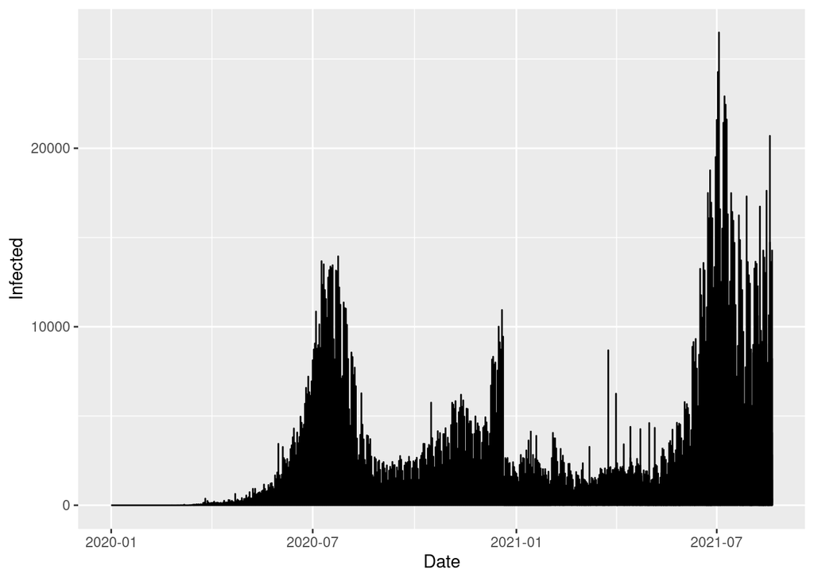

```r
# Create a basic epicurve using ggplot2
ggplot(covid19_africa, aes(x=Date,y=Infected)) +
  geom_line()
```

Executing the above R code will give us a basic line graph where the x-axis represents the date and the y-axis represents the number of infected individuals.

We employed the `geom_line()` which plots the data as a line graph. It ensures also the data points are connected, presenting a continuous view of the epidemic’s progression.

## 5.2 Enhancing the Visual: Crafting a Detailed Epicurve

But let’s not stop there. We can enhance the visual appeal and readability of our graph by incorporating some customizations:

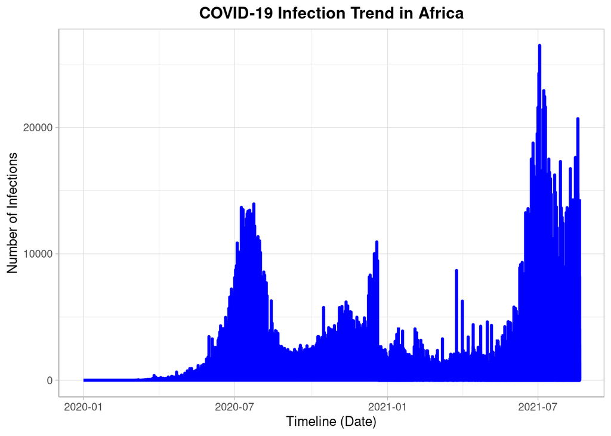

```r
# Refining the plot for clarity and appeal
ggplot(covid19_africa, aes(x = Date, y = Infected)) +
 geom_line(color = "blue", size = 1.2) +  # Modifying the line's aesthetics
 labs(title = "COVID-19 Infection Trend in Africa",  # Setting a descriptive title
       x = "Timeline (Date)", y = "Number of Infections") +    # Labeling the  axes comprehensively
 theme_light() +                   # Choosing a light,    distraction-free theme
 theme(plot.title = element_text(hjust = 0.5, face="bold"), # Enhancing the title's positioning and appearance
      axis.line = element_line(color = "grey"))  # Refining the appearance of the axis lines
```

As always with data visualization, these settings are malleable, and you can adapt them to resonate with your desired aesthetic and the nature of your data.

Great, now that you have a grasp on how to customize your epicurve, here’s a challenge to test your understanding and further enhance your skills.

Build a you own custmized epicurve by changing those components:

- *Line Color*: Instead of the current blue, try choosing a different color that represents urgency oconcern, like red. Alternatively, you can select any color that you find visually appealing.
- *Date Scale*: Instead of showing every single date, which might clutter the x-axis, try to display only specific intervals, say every month or every other week. This will make your graph much cleaner and more readable.

## 5.3 Spotlight on a Specific Duration:

In visual analytics, there are times when one wishes to emphasize a particular time frame or period to draw the viewer’s attention to specific trends or events. Highlighting a time frame can be useful, for example, when wanting to showcase a significant spike in cases, an important event, or perhaps, a policy’s impact on data.

For our current data visualization, let’s focus on a specific period during the year 2020, namely from April to September This period might be of interest for various reasons - perhaps it witnessed a significant event, a rise in cases, or a policy change.

Here’s how we visualize it:

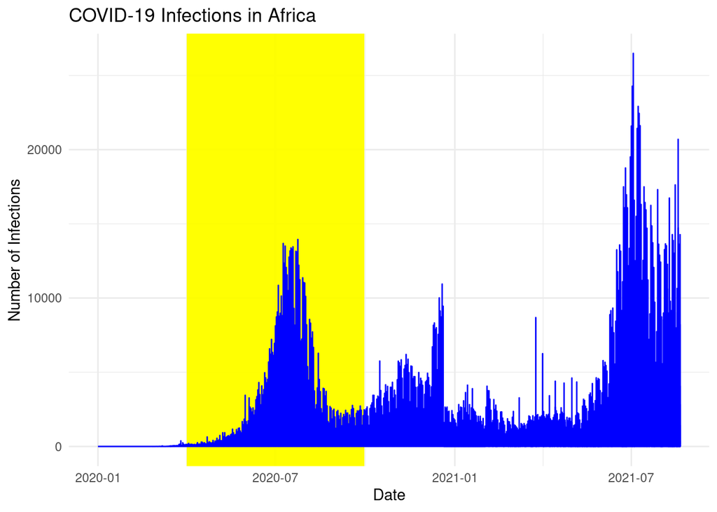

```r
# Setting the Time Frame:
# Defining the start and end dates for the period of interest.
start_date <- as_date("2020-04-01")
end_date <- as_date("2020-09-30")

# Creating the Graph:
# We'll represent our data using a line graph and overlay it with a shaded region that represents the period of interest.
ggplot(covid19_africa, aes(x = Date, y = Infected)) +
    geom_rect(aes(xmin=start_date, xmax=end_date, ymin=-Inf, ymax=Inf),
              fill="yellow", alpha=0.2, inherit.aes=TRUE) +  # Shaded area for emphasis
    geom_line(color = "blue", size = 0.5) +  # Data line
    labs(title = "COVID-19 Infections in Africa",
         x = "Date", y = "Number of Infections") +
    theme_minimal()
```

This enhanced visualization ensures that viewers can quickly discern the significance of the period in focus, set against the backdrop of the larger dataset.

## 5.4 Zooming in on a Particular Region/Country:

Focusing on specific regions or countries can offer a detailed perspective on local trends, thereby enabling a more nuanced understanding. For this exercise, we’ll zoom in on Northern Africa to analyze the progression of COVID-19 cases within this region.

Before visualizing, we need to filter our dataset to retain only data corresponding to Northern Africa.

```r
# Extracting data specific to Northern Africa
covid19_northern_africa <- filter(covid19_africa, Region == "Northern Africa")
```

Once we have the subset, we’ll create a line plot representing the number of cases in each country of Northern Africa over time.

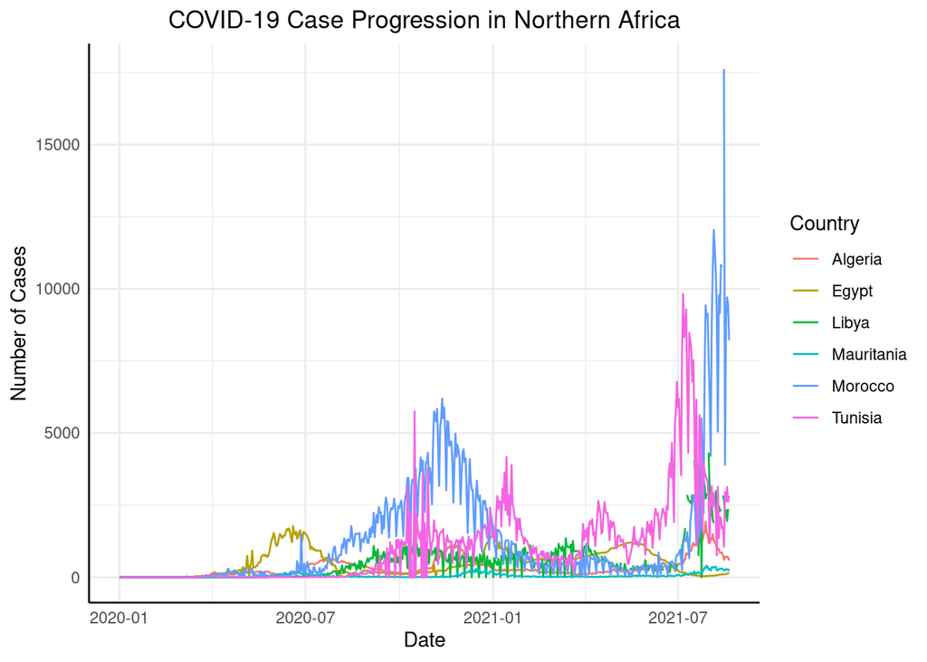

```r
# Start plotting using ggplot
ggplot(covid19_northern_africa, aes(x = Date, y = Infected, color = Country)) +  # Define the main plot aesthetics: x-axis as Date, y-axis as Infected, and color-coded by Country
  geom_line(size = 0.5) +  # Add a line for each country's infection numbers. Set the line width to 1 for readability.
  labs(title = "COVID-19 Case Progression in Northern Africa",  # Set the title of the plot
       x = "Date",  # Label for the x-axis
       y = "Number of Cases") +  # Label for the y-axis
  theme_minimal() +  # Apply a minimal theme for a clean look
  theme(plot.title = element_text(hjust = 0.5),  # Center the title of the plot
        axis.line = element_line(color = "black"),  # Set axis line color to black
        legend.position = "right")  # Position the legend to the right side of the plot
```

By zooming in on specific regions or countries, analysts, policymakers, and public health experts can closely monitor local trends and implement interventions tailored to regional conditions.

Practice Time! Can you craft a similar visualization for a different region, maybe “Central Africa”?

## 5.5 Fine-tuning the Time Axis

Visualization is as much an art as it is a science. At times, the default display may overwhelm with too much detail. In such cases, we might desire a less cluttered timeline, perhaps showing data points every few months.

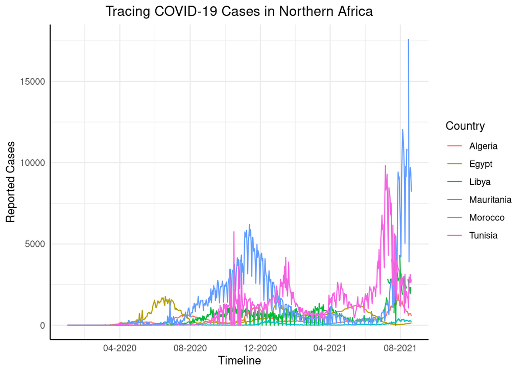

```r
# Modifying the date axis for clarity
ggplot(covid19_northern_africa, aes(x = Date, y = Infected, color = Country)) +
  geom_line() +
  labs(title = "Tracing COVID-19 Cases in Northern Africa",
       x = "Timeline", y = "Reported Cases") +
  scale_x_date(date_breaks = '4 months',
               date_labels = '%m-%Y') +
  theme_minimal() +
  theme(plot.title = element_text(hjust = 0.5),
        axis.line = element_line(color = "black"))
```

In ggplot2, the `scale_x_date()` function serves as a powerful tool to modify date representation on the x-axis. By playing with the `date_labels` parameter, you can dictate how dates get displayed. Some commonly used formats are: - `%Y`: Just the year (like “2023”). - `%m-%d`: Month and day, resembling “01-15”. - `%B`: The month in full (such as “January”). … and several others (see `?scale_x_date()`).

## 5.6 Breaking Down the Visualization of COVID-19 Spread by Country

When examining regional data, it’s often beneficial to emphasize information from a single country, while still retaining context from its neighbors. To demonstrate, let’s accentuate Morocco’s data.

For Establishing a color guide, we can use the `ifelse()` function to set Morocco’s color to red and all other countries to grey.

The `unique()` function ensures we’re not duplicating any color assignments.

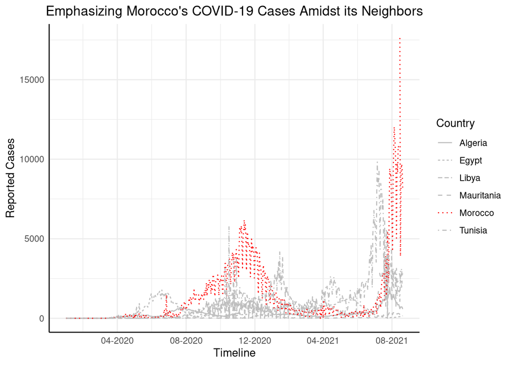

```r
# Establishing a color guide. Here we're using ifelse to set Morocco to red and all other countries to grey.
palette <- ifelse(unique(covid19_northern_africa$Country) == "Morocco", "red", "grey")

# Visualization emphasizing Morocco's data
ggplot(covid19_northern_africa, aes(x = Date, y = Infected, color = Country)) +
  geom_line(aes(linetype = Country)) +  # Different linetypes for different countries. This further distinguishes each country's data trajectory.
  scale_color_manual(values = palette) +  # Applying our custom color palette
  labs(title = "Emphasizing Morocco's COVID-19 Cases Amidst its Neighbors",
       x = "Timeline", y = "Reported Cases") +
  scale_x_date(date_breaks = '4 months',
               date_labels = '%m-%Y') +
  theme_minimal() +
  theme(plot.title = element_text(hjust = 0.5),
        axis.line = element_line(color = "black"))
```

Through this visualization technique, Morocco’s data line stands out in a bold red, while its neighboring countries in Northern Africa appear in a subdued grey. This contrast ensures that Morocco’s data trajectory can be immediately identified, even when presented alongside its regional counterparts.

## 5.7 Facettin Epidemic Curves

Visualizing data provides insights, but to extract the full story, we need to be precise about the details. When mapping out COVID-19 cases, it’s crucial to understand which curve corresponds to which country. So, how can we make these representations clearer?

One of the most effective ways is to display these epidemic curves individually. This can be achieved using the `facet_wrap()` function in R. It separates the data by country, dedicating a unique plot for each, which aids in a clearer understanding.

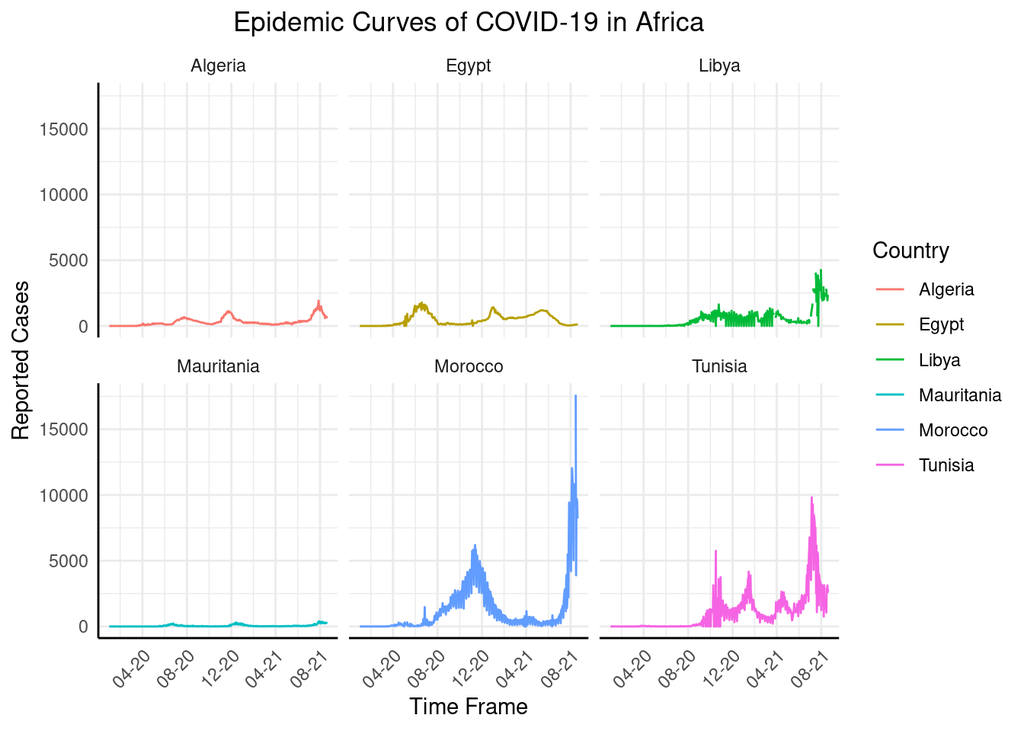

```r
ggplot(covid19_northern_africa, aes(x = Date, y = Infected, color = Country)) +
  # Add line graph for each country's data
  geom_line() +
  # Set plot and axis titles
  labs(title = "Epidemic Curves of COVID-19 in Africa",
       x = "Time Frame", y = "Reported Cases") +
  # Adjust x-axis date breaks and format
  scale_x_date(date_breaks = '4 months',
               date_labels = '%m-%y') +
  # Apply minimal theme
  theme_minimal() +
  # Additional theme adjustments
  theme(
    plot.title = element_text(hjust = 0.5),      # Center plot title
    axis.line = element_line(color = "black"),   # Black axis lines
    axis.text.x = element_text(angle = 45, hjust = 1)  # Rotate x-axis labels
  ) +
  # Separate plots for each country
  facet_wrap(~Country)
```

### 5.7.1 Tracking the Overall Spread:Cumulative Cases Visualization

Cumulative cases offer a broader perspective on the pandemic by presenting the total infections accumulated from the onset up to a particular date. By observing the cumulative data, one can discern not only daily changes but also the overall trajectory and magnitude of the outbreak.

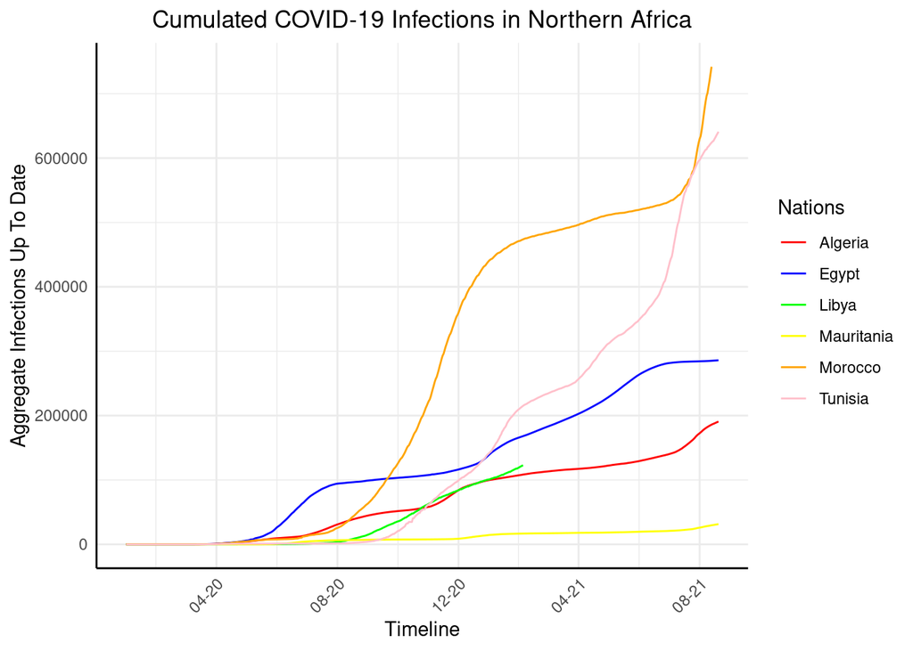

```r
# Specify countries and associated colors
highlighted_countries <- c("Algeria", "Egypt", "Libya", "Mauritania", "Morocco", "Tunisia")
highlighted_colors <- c("red", "blue", "green", "yellow", "orange", "pink")


# Computing the running total of cases for each country
covid19_northern_africa_cumulative <- covid19_northern_africa %>%
    group_by(Country) %>%
    arrange(Date) %>%
    mutate(Cumulative_Infected = cumsum(Infected))

# Crafting the visualization for cumulative cases
ggplot(covid19_northern_africa_cumulative, aes(x = Date, y = Cumulative_Infected, color = Country)) +
    geom_line() +
    labs(title = "Cumulated COVID-19 Infections in Northern Africa",
         x = "Timeline", y = "Aggregate Infections Up To Date") +
    scale_color_manual(values = setNames(highlighted_colors, highlighted_countries),
                       guide = guide_legend(title = "Nations")) +
    scale_x_date(date_breaks = '4 months',
                 date_labels = '%m-%y') +
    theme_minimal() +
    theme(plot.title = element_text(hjust = 0.5),
          axis.line = element_line(color = "black"),
          axis.text.x = element_text(angle = 45, hjust = 1))
```

This graph’s unique value lies in its representation of total cases up to any chosen point in time for each nation. By juxtaposing daily increments with accumulated totals, those analyzing the data can derive a more comprehensive understanding of the virus’s spread and its potential impact on the region.

## 5.8 Diving Deeper with Specific Countries

### 5.8.1 Why Transform Data Formats?

When working with time-series data, particularly for different variables like “Recovered,” “Infected,” and “Death,” it’s sometimes easier to work with the data in a “long” format rather than a “wide” format.

- **Wide Format:** Here, each row represents an observation with a column for every variable. For instance, you’d have separate columns for “Recovered,” “Infected,” and “Death.”
- **Long Format:** In this format, each row is a single observation for a particular variable. So, for a given date, you’d have separate rows for “Recovered,” “Infected,” and “Death.”

### 5.8.2 How to Transform the Data?

The `gather()` function from the `tidyr` package in R is a handy tool for this transformation. It helps convert data from the wide format to the long format.

```r
# Load the tidyr package
library(tidyr)

# Transform the data
covid_long <- covid19_northern_africa %>%
  select(Country, Date, Recovered, Infected, Death) %>%  # Select relevant columns
  gather(Case_Type, Cases, c(Recovered, Infected, Death))  # Convert to long format

# Display the transformed data
covid_long
```

```
## # A tibble: 10,764 × 4
##    Country Date       Case_Type Cases
##    <chr>   <date>     <chr>     <dbl>
##  1 Algeria 2020-01-01 Recovered     0
##  2 Algeria 2020-01-02 Recovered     0
##  3 Algeria 2020-01-03 Recovered     0
##  4 Algeria 2020-01-04 Recovered     0
##  5 Algeria 2020-01-05 Recovered     0
##  6 Algeria 2020-01-06 Recovered     0
##  7 Algeria 2020-01-07 Recovered     0
##  8 Algeria 2020-01-08 Recovered     0
##  9 Algeria 2020-01-09 Recovered     0
## 10 Algeria 2020-01-10 Recovered     0
## # ℹ 10,754 more rows
```

In the transformed `covid_long` data frame, the `Case_Type` column will specify the type of case (i.e., “Recovered,” “Infected,” or “Death”), and the `Cases` column will indicate the corresponding count for that type on a given date. This structure is particularly beneficial when plotting data to discern patterns and trends over time for each case type.

## 5.9 Visualizing Combined Trends with Area Plots

Understanding the evolution of multiple indicators over time can be a challenging task. Especially when these indicators are interrelated, it’s essential to present the data in a manner that’s easy to comprehend. Here, the area plot comes to the rescue.

An area chart effectively illustrates the magnitude of change over time for one or more series. By emphasizing the area between lines with colors or hatchings, it draws attention to the total value across a trend. It’s especially useful when comparing two or more correlated indicators, as the filled areas provide a clear visual representation of the differences between them.

For a hands-on understanding, let’s focus on the COVID-19 data for Morocco, concentrating specifically on “Infected” and “Recovered” cases.

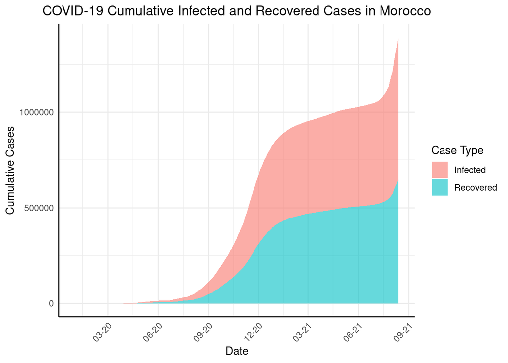

```r
# Filter out data specific to Morocco and the case types "Infected" and "Recovered"
morocco_data <- covid_long %>%
    filter(Country == "Morocco", Case_Type %in% c("Infected", "Recovered"))

# Cumulatively sum the cases for a comprehensive view
morocco_data <- morocco_data %>%
    group_by(Case_Type) %>%
    arrange(Date) %>%
    mutate(Cumulative_Cases = cumsum(Cases))

# Plot the data using an area plot
ggplot(morocco_data, aes(x = Date, y = Cumulative_Cases, fill = Case_Type)) +
    geom_area(alpha = 0.6) +  # 'geom_area()' fills the area under the curve; 'alpha' controls the transparency
    labs(title = "COVID-19 Cumulative Infected and Recovered Cases in Morocco",
         x = "Date",
         y = "Cumulative Cases",
         fill = "Case Type") +
    theme_minimal() +
    theme(plot.title = element_text(hjust = 0.5),
          axis.line = element_line(color = "black"),
          axis.text.x = element_text(angle = 45, hjust = 1)) +
    scale_x_date(date_breaks = '3 months', date_labels = '%m-%y')
```

In this plot, the filled areas for “Infected” and “Recovered” cases offer a visual representation of how the pandemic unfolded in Morocco, showing the extent of infections and recoveries side by side. This visualization technique can be invaluable in deciphering patterns and making informed decisions.

## 5.10 Incorporating a Secondary Y-Axis

In data visualization, especially when dealing with multiple data series that have different scales but are related, it’s often challenging to depict them on a single plot without one overshadowing the other. Here is where a secondary Y-axis can be invaluable.

From an epidemiological perspective, using a secondary Y-axis allows researchers and decision-makers to simultaneously observe two different yet interrelated metrics. For instance, when studying an infectious disease, it’s crucial not just to know the number of infected individuals, but also to understand other metrics like the death rate. This duality provides a holistic view of the disease’s impact.

While the raw count of cases can provide an understanding of the disease’s spread, the death rate (usually expressed as a percentage) can give insights into the disease’s severity, the effectiveness of treatments, and the health system’s capacity.

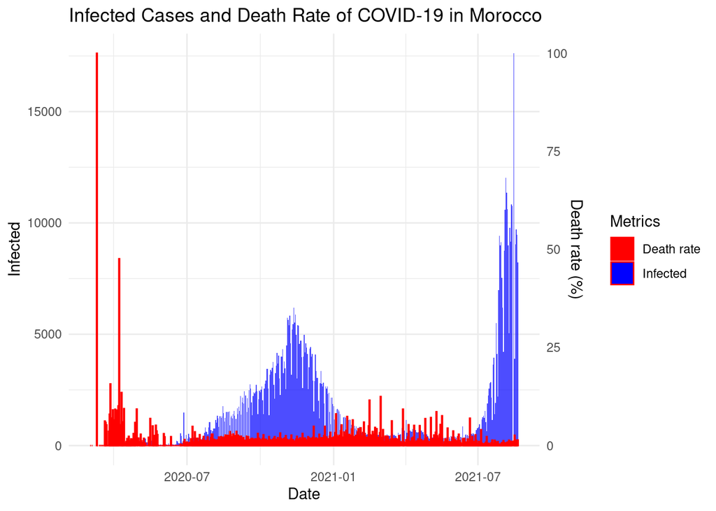

```r
# Filter and preprocess data for Morocco
morocco_death_rate <- covid19_africa %>%
  filter(Country == "Morocco") %>%
  select(Date, Infected, Death) %>%
  mutate(Death_rate = ((Death / (Infected))*100)) %>%
    na.omit()

# Compute the maximum values for both the infected cases and death rate
max_cases <- max(morocco_death_rate$Infected)
max_rate <- max(morocco_death_rate$Death_rate)

# Define a scaling factor based on the ratio of maximum infected cases to the maximum death rate
scaling_factor <- max_cases / max_rate
library(ggplot2)

# Construct the plot
ggplot(data = morocco_death_rate, aes(x = Date)) +
  # Bar plot representing the number of infected individuals
  geom_col(aes(y = Infected, fill = "Infected"), alpha = 0.7) +
  # Line plot for the death rate (scaled by the previously defined factor)
  geom_col(aes(y = Death_rate * scaling_factor, fill = "Death rate"), color = "red") +
  # Add a secondary y-axis for the death rate
  scale_y_continuous(name = "Infected",
                     sec.axis = sec_axis(~./scaling_factor, name = "Death rate (%)")) +
  labs(title = "Infected Cases and Death Rate of COVID-19 in Morocco",
       x = "Date") +
  theme_minimal() +
  scale_fill_manual(values = c("Infected" = "blue", "Death rate" = "red")) +
  scale_color_manual(values = c("Infected" = "blue", "Death rate" = "red")) +
  guides(fill = guide_legend(title = "Metrics"))
```

In this visualization, the primary Y-axis depicts the infected count, while the secondary Y-axis (on the right side) displays the death rate. This dual representation provides a comprehensive snapshot of the COVID-19 situation in Morocco, enabling a better understanding of the disease’s trajectory and impact. However, it’s essential to note that while dual y-axes can be informative, they can also sometimes lead to misinterpretations if not labeled and scaled appropriately. Always ensure clarity when using this approach.

However, a word of caution: dual y-axes, while powerful, demand careful construction to avoid misinterpretation. Proper scaling and labeling are paramount to ensure viewers grasp the data’s essence without misconstruing relationships or magnitudes.

# WRAP UP!

## 5.11 Visualization and Analysis of Epidemiological Data: A Wrap-Up

The journey through these sections provided a comprehensive dive into the world of data visualization, specifically tailored to epidemiological time series. Here’s a brief wrap-up of the key insights and methodologies we’ve explored:

- We began by understanding the significance of “epicurves” which are foundational in epidemiological studies to track the progress of diseases.
- The use of `facet_wrap()` allows us to neatly categorize data from different countries, providing a side-by-side comparison of disease progression.

- The area plot was introduced as a powerful tool to represent bivariate or multivariate data over time.
- Through the Morocco case study, we demonstrated how area plots can effectively display the evolution of multiple interlinked indicators, such as infection and recovery rates.

- Dual Y-axes have a unique advantage in simultaneously visualizing two related metrics with different scales.
- From an epidemiological perspective, this approach provides a comprehensive view, for example, comparing raw infection counts with death rates as percentages.

# Answer Key

## 5.12 Building a Customized Epicurve

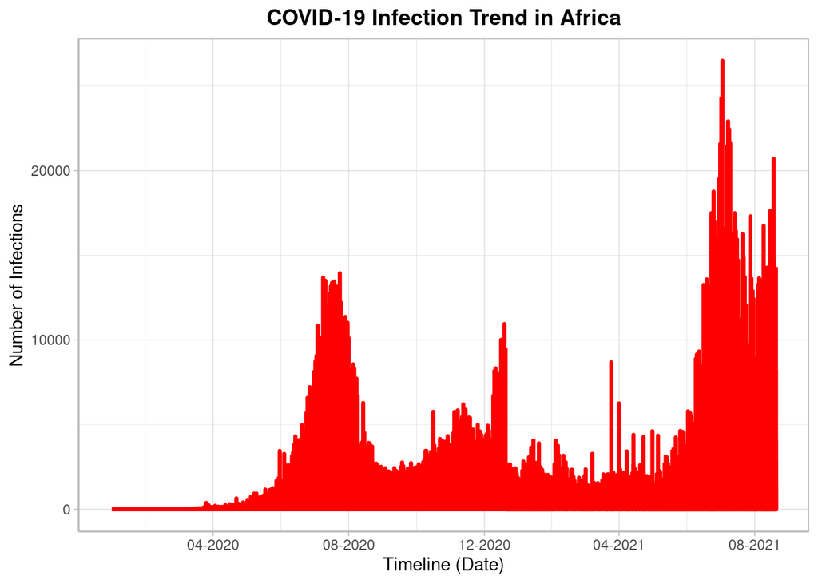

```r
# Constructing a customized epicurve
ggplot(covid19_africa, aes(x = Date, y = Infected)) +
  # Changing the line color to red
  geom_line(color = "red", size = 1.2) +

  # Setting a descriptive title and labeling the axes
  labs(title = "COVID-19 Infection Trend in Africa",
       x = "Timeline (Date)", y = "Number of Infections") +

  # Choosing a light theme for clarity
  theme_light() +

  # Enhancing the title's appearance and positioning the axis lines
  theme(plot.title = element_text(hjust = 0.5, face="bold"),
        axis.line = element_line(color = "grey")) +

  # Adjusting the x-axis to display dates at monthly intervals
  scale_x_date(date_breaks = '4 month', date_labels = '%m-%Y')
```

# Contributors

The following team members contributed to this lesson:

- [IMAD EL BADISY](https://thegraphcourses.org/members/ielbadisy/)  
  Data Science Education Officer

  Deeply interested in health data
- [JOY VAZ](https://thegraphcourses.org/members/joy)  
  R Developer and Instructor, the GRAPH Network

  Loves doing science and teaching science
- [KENE DAVID NWOSU](https://thegraphcourses.org/members/kendavidn/)  
  Data analyst, the GRAPH Network

  Passionate about world improvement